# Week 1 Exercise: SF Salaries

### Step 1: Import libraries: pandas and seaborn

```python
import pandas as pd
import seaborn as sns
```

### Step 2: Read Data

#### If you are using Jupyter notebook:

first save the salaries.csv to your local folder:

sal = pd.read_csv("`your path here`/salaries.csv")

#### If you are using google colab, please mount your Google Drive on your runtime using an authorization code:

from google.colab import drive

drive.mount('/content/drive')

path = '/content/drive/`your path here`/salaries.csv'

sal = pd.read_csv(path)

#### Feel free to use any other prefered IDEs for python.

```python
sal = pd.read_csv('C:/Users/apere/OneDrive/Desktop/CIS 508/Salaries.csv')
```

### Step 3: Follow the instructions below and answer questions.

**Check the head of the DataFrame**

##### code for reference:

sal.head()

```python
sal.head()
```

|  | Id | EmployeeName | JobTitle | BasePay | OvertimePay | OtherPay | Benefits | TotalPay | TotalPayBenefits | Year | Agency | Status |
| --- | --- | --- | --- | --- | --- | --- | --- | --- | --- | --- | --- | --- |
| 0 | 1 | NATHANIEL FORD | GENERAL MANAGER-METROPOLITAN TRANSIT AUTHORITY | 167411.18 | 0.00 | 400184.25 | NaN | 567595.43 | 567595.43 | 2011 | San Francisco | NaN |
| 1 | 2 | GARY JIMENEZ | CAPTAIN III (POLICE DEPARTMENT) | 155966.02 | 245131.88 | 137811.38 | NaN | 538909.28 | 538909.28 | 2011 | San Francisco | NaN |
| 2 | 3 | ALBERT PARDINI | CAPTAIN III (POLICE DEPARTMENT) | 212739.13 | 106088.18 | 16452.60 | NaN | 335279.91 | 335279.91 | 2011 | San Francisco | NaN |
| 3 | 4 | CHRISTOPHER CHONG | WIRE ROPE CABLE MAINTENANCE MECHANIC | 77916.00 | 56120.71 | 198306.90 | NaN | 332343.61 | 332343.61 | 2011 | San Francisco | NaN |
| 4 | 5 | PATRICK GARDNER | DEPUTY CHIEF OF DEPARTMENT,(FIRE DEPARTMENT) | 134401.60 | 9737.00 | 182234.59 | NaN | 326373.19 | 326373.19 | 2011 | San Francisco | NaN |

**Q1: How many columns and rows are there in the dataset?**

##### code for reference:

sal.shape

```python
sal.shape
```

```
(148654, 12)
```

**Q2: What the average of total pay ['TotalPay'] of San Francisco’s city employees?**

##### code for reference:

You can either use:

sal.desribe() or

sal["TotalPay"].mean()

```python
sal["TotalPay"].mean()
```

```
74768.321971703
```

##### code for reference:

sal.desribe() or

sal['Benefits'].max()

```python
sal['TotalPay'].max()
```

```
567595.43
```

**Q4: How much benefits did JOSEPH DRISCOLL receive?** (Hint: Use 'TotalPayBenefits' variable)

##### code for reference:

sal[sal['EmployeeName']=='JOSEPH DRISCOLL']['TotalPayBenefits']

```python
sal[sal['EmployeeName']=='JOSEPH DRISCOLL']['TotalPayBenefits']
```

```
24    270324.91
Name: TotalPayBenefits, dtype: float64
```

**Q5: What is the average ’total benefits’ received by Special Nurse?**

##### code for reference

sal[sal['JobTitle']=='Special Nurse']['TotalPayBenefits'].mean()

```python
sal[sal['JobTitle']=='Special Nurse']['TotalPayBenefits'].mean()
```

```
36372.276962861666
```

**Q6: What is the name of the employee in the 3500th record?**

##### code for reference

sal.iloc[ ]

```python
sal.iloc[:3500]
```

|  | Id | EmployeeName | JobTitle | BasePay | OvertimePay | OtherPay | Benefits | TotalPay | TotalPayBenefits | Year | Agency | Status |
| --- | --- | --- | --- | --- | --- | --- | --- | --- | --- | --- | --- | --- |
| 0 | 1 | NATHANIEL FORD | GENERAL MANAGER-METROPOLITAN TRANSIT AUTHORITY | 167411.18 | 0.00 | 400184.25 | NaN | 567595.43 | 567595.43 | 2011 | San Francisco | NaN |
| 1 | 2 | GARY JIMENEZ | CAPTAIN III (POLICE DEPARTMENT) | 155966.02 | 245131.88 | 137811.38 | NaN | 538909.28 | 538909.28 | 2011 | San Francisco | NaN |
| 2 | 3 | ALBERT PARDINI | CAPTAIN III (POLICE DEPARTMENT) | 212739.13 | 106088.18 | 16452.60 | NaN | 335279.91 | 335279.91 | 2011 | San Francisco | NaN |
| 3 | 4 | CHRISTOPHER CHONG | WIRE ROPE CABLE MAINTENANCE MECHANIC | 77916.00 | 56120.71 | 198306.90 | NaN | 332343.61 | 332343.61 | 2011 | San Francisco | NaN |
| 4 | 5 | PATRICK GARDNER | DEPUTY CHIEF OF DEPARTMENT,(FIRE DEPARTMENT) | 134401.60 | 9737.00 | 182234.59 | NaN | 326373.19 | 326373.19 | 2011 | San Francisco | NaN |
| ... | ... | ... | ... | ... | ... | ... | ... | ... | ... | ... | ... | ... |
| 3495 | 3496 | TIMOTHY LIPPS | TRANSIT POWER LINE WORKER SUPERVISOR II | 107916.00 | 25657.52 | 2233.00 | NaN | 135806.52 | 135806.52 | 2011 | San Francisco | NaN |
| 3496 | 3497 | GARY ALTENBERG | FIREFIGHTER | 123028.00 | 5065.76 | 7691.20 | NaN | 135784.96 | 135784.96 | 2011 | San Francisco | NaN |
| 3497 | 3498 | DANIEL EVERSON | INSPECTOR III, (POLICE DEPARTMENT) | 130481.58 | 489.89 | 4812.88 | NaN | 135784.35 | 135784.35 | 2011 | San Francisco | NaN |
| 3498 | 3499 | LAWRENCE LAU | MAINTENANCE MACHINIST | 74651.50 | 56722.22 | 4390.00 | NaN | 135763.72 | 135763.72 | 2011 | San Francisco | NaN |
| 3499 | 3500 | DANNY LOPEZ | SERGEANT III (POLICE DEPARTMENT) | 130457.64 | 943.62 | 4340.11 | NaN | 135741.37 | 135741.37 | 2011 | San Francisco | NaN |

3500 rows × 12 columns

**Q7: How many missing values does variable 'BasePay' have?**

##### code for reference

sal.isnull().sum()

```python
sal.isnull().sum()
```

```
Id                       0
EmployeeName             6
JobTitle                 4
BasePay                609
OvertimePay              4
OtherPay                 4
Benefits             36163
TotalPay                 0
TotalPayBenefits         0
Year                     0
Agency                   0
Status              110535
dtype: int64
```

**Q8: Create a boxplot of TotalPay variable across different job status (Status). Which of the following statements is NOT true?**

##### code for reference

sns.boxplot(x=,y=,data=)

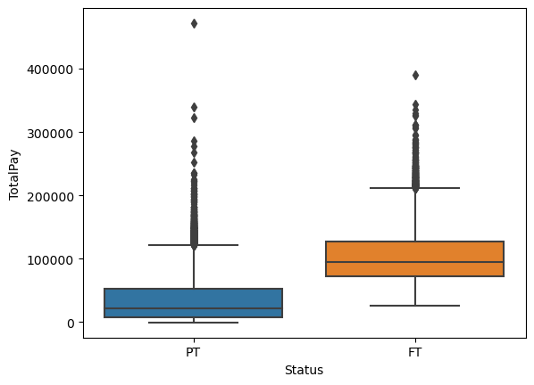

```python
sns.boxplot(x='Status',y='TotalPay',data=sal)
```

**Q9: Create a boxplot of BasePay variable across different years (Year variable). Which of the following statement is NOT true?**

##### code for reference

sns.boxplot(x=,y=,data=)

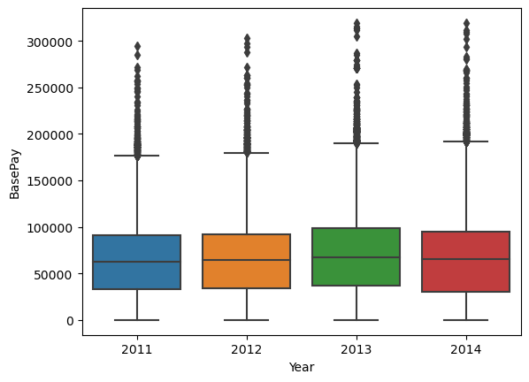

```python
sns.boxplot(x='Year',y='BasePay',data=sal)
```

**Q10: Create a histogram for TotalPay variable. Which of the following statement is NOT true?**

##### code for reference

sns.histplot(sal['variable name here'])

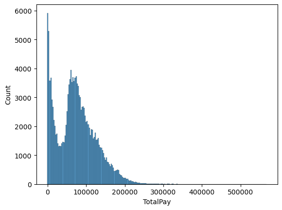

```python
sns.histplot(sal['TotalPay'])
```